# Introducción a R

Benjamin Oliva & Omar Alfaro-Rivera

17/8/2023

## Algunas reglas importantes:

1. R es case sensitive, esto significa que **distingue entre minusculas y mayusculas**
2. Para escribir pedazos de código, es necesario hacerlo entre

````r
#```{r}
#```
````

3. Para **ejecutar una linea** de comando se utiliza “Ctrl + Enter”
4. Para **limpiar la Consola** se utiliza “Ctrl + L”
5. Utilizar *“;”* funciona para realizar más de una tarea en la misma línea de código
6. En R existen un conjunto de **palabras reservadas**, como lo son: break, for, function, if, in, next, repeat, return, while, True, False, y algunas otras

## Objetos

### Clases de objetos

Un hecho fundamental de la programación en R es contar con un buen manejo de los distintos tipos de objetos y sus propiedades. Estos son los tipos de objetos básicos

- character: Es un tipo de objeto cuya información es interpretada como texto
- numeric: números reales
- logic : TRUE/FALSE, objetos que son producto de realizar una evaluación de tipo lógica
- integer: números enteros
- complex: números complejos

```r
class("R")
```

```
## [1] "character"
```

```r
class(56)
```

```
## [1] "numeric"
```

```r
class("R">"Python")
```

```
## [1] "logical"
```

```r
class(as.integer(2))
```

```
## [1] "integer"
```

```r
class(sqrt(5)*as.complex(1))
```

```
## [1] "complex"
```

### Asignación e impresión de objetos

Otra cuestión importante es que la información que nosotros tenemos en R, es necesario *asignarle un nombre*, a esto le llamamos asignación de objetos y lo hacemos mediante el símbolo “<-” o “=”

```r
ObjetoGuardado = 5
#Forma tradicional de imprimir en R
print(ObjetoGuardado)
```

```
## [1] 5
```

```r
#En R Studio es suficiente con escribir el nombre del objeto en la consola
ObjetoGuardado
```

```
## [1] 5
```

### Objetos de tipo funciones

Un tipo muy peculiar de objeto son las funciones, ya que estos objetos operan sobre otros objetos para generar un producto

```r
class(class)
```

```
## [1] "function"
```

Lo que declaramos dentro de la función se conoce como argumentos, donde básicamente definicmos sobre qué objeto debe operar la función y el modo en que queremos que actúe. En la mayoría de funciones, a menos de que seamos específicos, el programa dará por hecho algunos argumentos.

```r
pi
```

```
## [1] 3.141593
```

```r
round(pi,2)
```

```
## [1] 3.14
```

```r
args(round)
```

```
## function (x, digits = 0)
## NULL
```

```r
round(pi,2)
```

```
## [1] 3.14
```

### Operadores Matemáticos

Los operadores matemáticos en R son en algunos casos un tanto distinto a la manera en que estamos acostumbrados a observarlos, pero en muchos otros casos son muy intuitivos:

- suma y resta: +,-
- multiplicación y división: *,/
- potencia y raíz cuadrada: **,sqrt()
- exponencial y logaritmo: exp(), log()

```r
ObjetoGuardado = 1:10
ObjetoGuardado*5
```

```
##  [1]  5 10 15 20 25 30 35 40 45 50
```

```r
ObjetoGuardado**(1/2)
```

```
##  [1] 1.000000 1.414214 1.732051 2.000000 2.236068 2.449490 2.645751 2.828427
##  [9] 3.000000 3.162278
```

```r
log(ObjetoGuardado)
```

```
##  [1] 0.0000000 0.6931472 1.0986123 1.3862944 1.6094379 1.7917595 1.9459101
##  [8] 2.0794415 2.1972246 2.3025851
```

### Operadores lógicos

Un elemento de gran importancia dentro de un entorno de trabajo como *R*, son los operadores lógicos. De los cuales tenemos como más importantes los siguientes:

- Coincidencia exacta (==)
- mayor o igual (>=)
- menor o igua (<=)
- Es distinto (!=)
- Y (&)
- O (|)
- Existe en (%in%)

```r
2+2 == 5
```

```
## [1] FALSE
```

```r
2+2 != 5
```

```
## [1] TRUE
```

```r
2+2 >= 5
```

```
## [1] FALSE
```

```r
(2+2 == 5) & (2+2 <=5)
```

```
## [1] FALSE
```

```r
FALSE & TRUE
```

```
## [1] FALSE
```

```r
FALSE | TRUE
```

```
## [1] TRUE
```

```r
secuencia = 1:10
secuencia %in% 3
```

```
##  [1] FALSE FALSE  TRUE FALSE FALSE FALSE FALSE FALSE FALSE FALSE
```

### Arreglos de datos de una y multiple clase de objetos

Generalmente necesitamos utilizar objetos que contengan multiples datos, para este efecto existen los vectores y las listas, en ambos casos los podemos generar con la función **c()** (combine) que nos ayuda a combinar distintos objetos dentro de uno solo:

- vector: objetos que sólo pueden contener un tipo de datos y guardan la clase de datos de los elementos, los conseguimos con la función *c()* (combine).
- list: objetos que pueden contener multiples tipos de datos, son objetos de tipo *list* y los generamos con la función que lleva este nombre(list())

```r
secuencia = c(1,2,3,"R")
class(secuencia)
```

```
## [1] "character"
```

```r
fruta = list("Naranja", 18, TRUE)
class(fruta)
```

```
## [1] "list"
```

## Arreglos de datos bidimensionales

Los tipos de objetos que se observan en el apartado anterior tienen la característica de ser arreglos de datos de una sola dimensión. Para los fines de esta clase, con mayor frecuencia utilizaremos arreglos bidimencionales (con filas y columnas). Los objetos de este tipo más utilizados son las matrices y los data frames

- matrix: objetos bidimensionales que sólo son capaces de tener un solo tipo de datos.
- DataFrame: arreglos bidimensionales que pueden contener distintos tipos de datos en cada columna.

```r
vector = 1:16
M_object <-matrix(vector, ncol=4) #Generamos una matriz a partir del vector
M_object
```

```
##      [,1] [,2] [,3] [,4]
## [1,]    1    5    9   13
## [2,]    2    6   10   14
## [3,]    3    7   11   15
## [4,]    4    8   12   16
```

```r
diagonal <- diag(4) #Generamos una matríz identidad de 3*3
M_object%*%diagonal
```

```
##      [,1] [,2] [,3] [,4]
## [1,]    1    5    9   13
## [2,]    2    6   10   14
## [3,]    3    7   11   15
## [4,]    4    8   12   16
```

```r
data(iris)
head(iris)
```

```
##   Sepal.Length Sepal.Width Petal.Length Petal.Width Species
## 1          5.1         3.5          1.4         0.2  setosa
## 2          4.9         3.0          1.4         0.2  setosa
## 3          4.7         3.2          1.3         0.2  setosa
## 4          4.6         3.1          1.5         0.2  setosa
## 5          5.0         3.6          1.4         0.2  setosa
## 6          5.4         3.9          1.7         0.4  setosa
```

```r
class(iris)
```

```
## [1] "data.frame"
```

```r
class(iris$Sepal.Length)
```

```
## [1] "numeric"
```

```r
class(iris$Species)
```

```
## [1] "factor"
```

### Funciones creadas

Un elemento particularmente poderoso de R, es la facilidad con la que podemos transitar de usuarios a desarrolladores. Seguramente el primer paso para este cometido es la creación de funciones.

Como se mostró en el apartado de operadores numéricos, las raices sólo mantienen la capacidad se extraer la raíz cuadrada. La siguiente linea de condigo genera una función que nos permite calcular raíces de orden *n*, utilizando dos argumentos: el objeto sobre el cual se realiza el cálculo, el orden de la raíz.

```r
raiz = function(x, n = 2){
  x**(1/n)
}
```

Observemos los resultados en una gráfica para tener una mejor vista de los resultados:

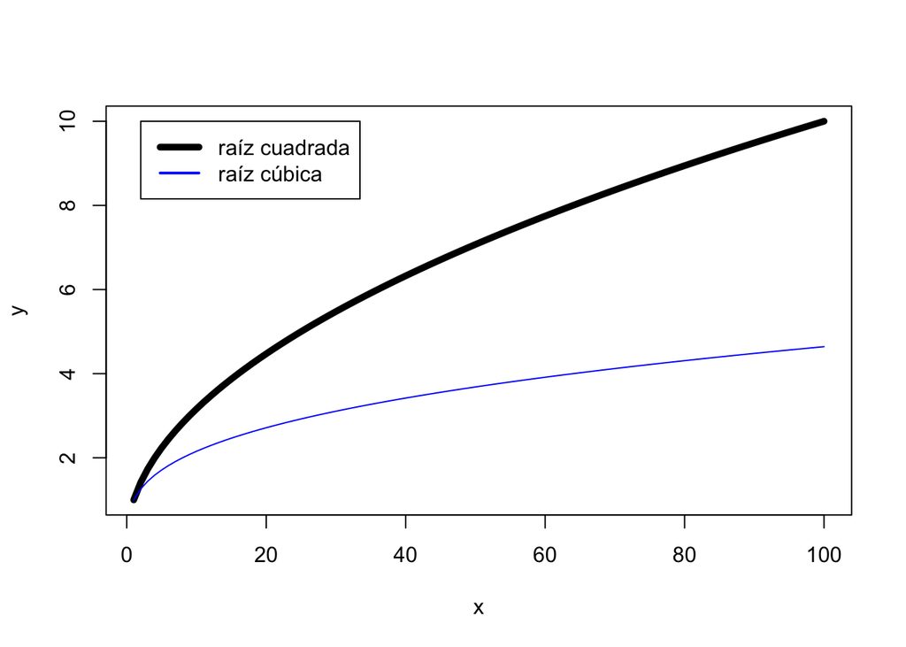

```r
x = 1:100
y = raiz(x)
y2 = raiz(x,3)

plot(x,y, type = "l", lwd =5 )
lines(x,y2, col = "blue")
legend(2,10,c("raíz cuadrada","raíz cúbica"), lwd=c(5,2), col=c("black","blue"), y.intersp=1)
```

### librerías

Del mismo modo en que nosotros somos capaces de escribir funciones nuevas, multiples usuarios constantemente crean o actualizan *librerias* para disminuir la cantidad de código que tiene que ser escrita. Básicamente las librerias ayudan a la comunidad de usuarios de R a tener mejores resultados sin tener que duplicar esfuerzos.

Un gran ejemplo de ello es *ggplot2*, que actualmente es de las librerías más populares de R por permitir generar elementos visuales muy estéticos de un modo muy simple.

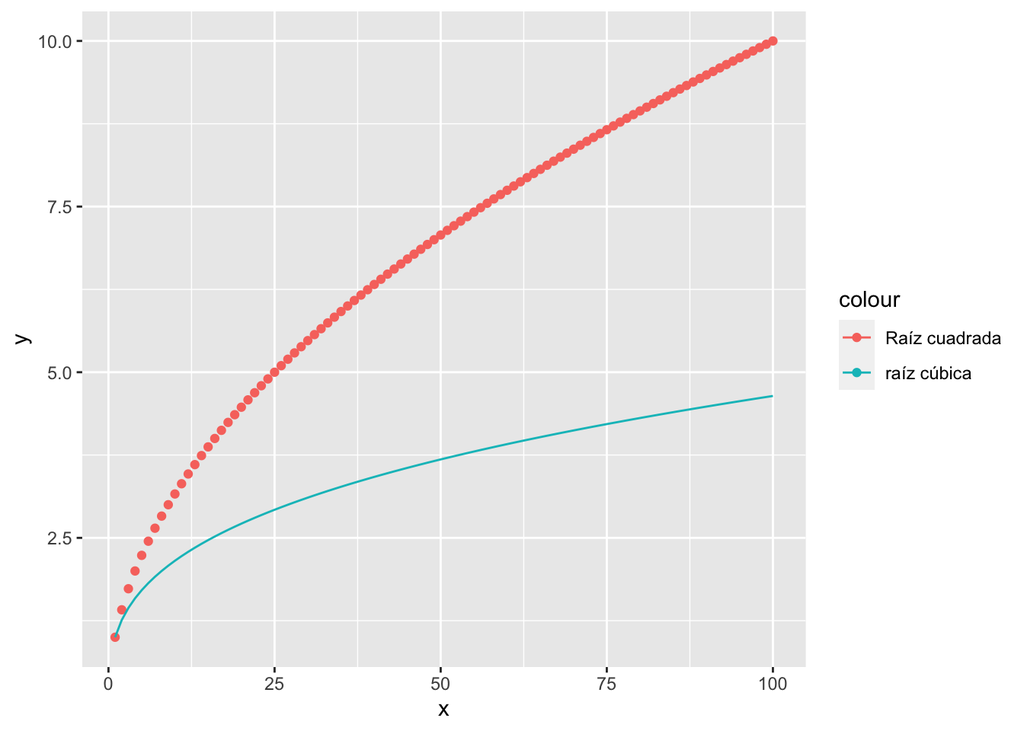

```r
#install.packages("ggplot2")
library(ggplot2)

qplot(x,y, col = "Raíz cuadrada")+
  geom_line(aes(x,y2,col = "raíz cúbica"))
```

## Caso Práctico (Cálculo de riesgo sistémico de AMZN)

### Obtención y exploración de datos

```r
getSymbols("AMZN")
```

```
## [1] "AMZN"
```

```r
head(AMZN, 2)
```

```
##            AMZN.Open AMZN.High AMZN.Low AMZN.Close AMZN.Volume AMZN.Adjusted
## 2007-01-03    1.9340     1.953   1.9025      1.935   248102000         1.935
## 2007-01-04    1.9295     1.957   1.9130      1.945   126368000         1.945
```

```r
hchart(AMZN)
```

[interactive chart not shown]

Descargamos la serie de las acciones de Nasdaq

```r
getSymbols("NDAQ")
```

```
## [1] "NDAQ"
```

```r
head(NDAQ, 2)
```

```
##            NDAQ.Open NDAQ.High NDAQ.Low NDAQ.Close NDAQ.Volume NDAQ.Adjusted
## 2007-01-03  10.38000  10.53000 10.28333   10.33667    16054800      8.596954
## 2007-01-04  10.35667  10.66667 10.16667   10.63000     9840900      8.840916
```

```r
### Gráfico
hchart(NDAQ)
```

[interactive chart not shown]

## Series en Diferencias

```r
lnAMZN <- log(AMZN$AMZN.Adjusted)
diffAMZN <- lnAMZN- Lag(lnAMZN)
lnNDAQ <- log(NDAQ$NDAQ.Adjusted)
diffNDAQ <- lnNDAQ - Lag(lnNDAQ)
```

### Gráfico de series en diferencia

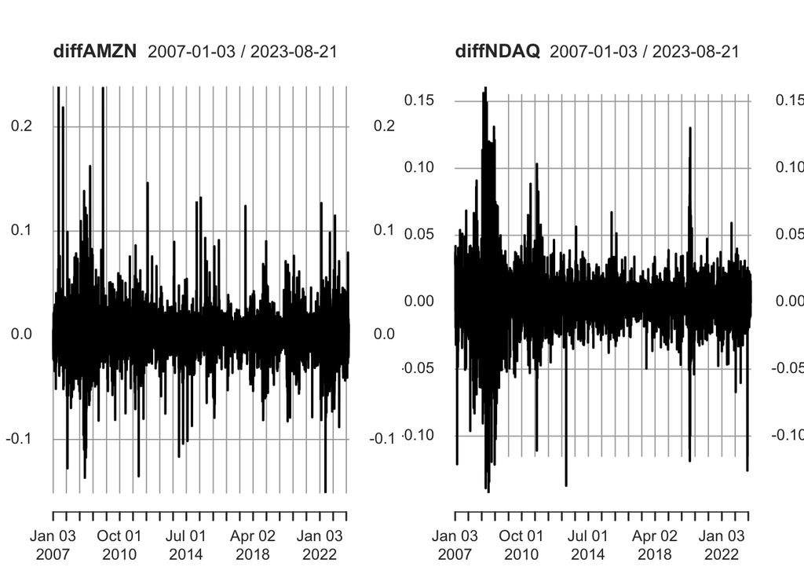

```r
par(mfrow=c(1,2))
plot(diffAMZN)
plot(diffNDAQ)
```

construir scatter plot de ambas series

```r
class(AMZN)
```

```
## [1] "xts" "zoo"
```

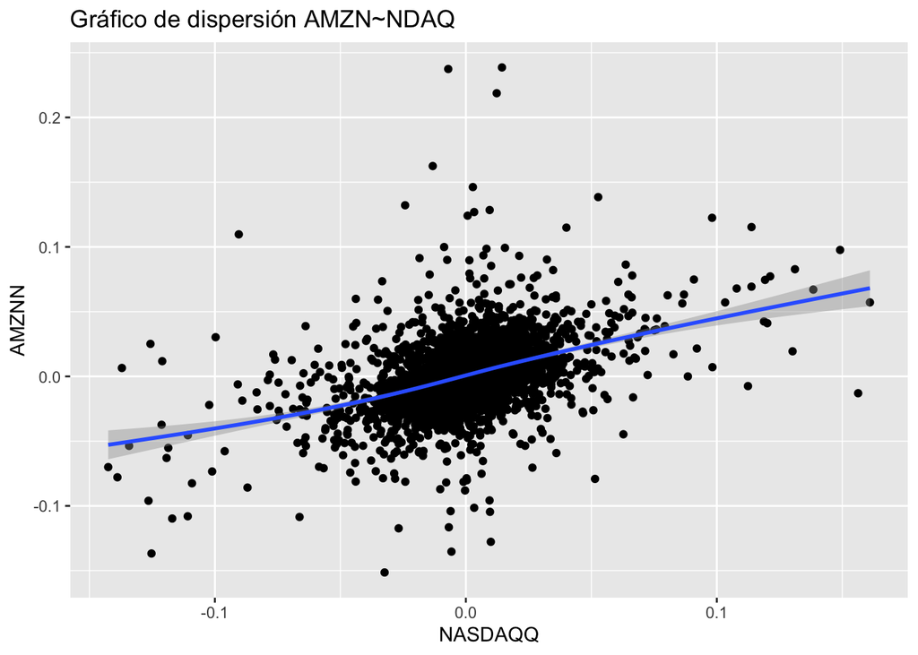

```r
AMZNN<-as.numeric(diffAMZN); NASDAQQ<-as.numeric(diffNDAQ)
### Análisis exploratorio de datos
qplot(x=NASDAQQ, y=AMZNN)+
  geom_smooth()+
    labs(title="Gráfico de dispersión AMZN~NDAQ")
```

### Para generar OLS

```r
reg1 <- lm(AMZNN~NASDAQQ)
stargazer(reg1, type = "html" )
```

|  | *Dependent variable:* |
| --- | --- |
|  | AMZNN |
| NASDAQQ | 0.461*** |
|  | (0.015) |
| Constant | 0.001** |
|  | (0.0003) |
| Observations | 4,186 |
| R<sup>2</sup> | 0.177 |
| Adjusted R<sup>2</sup> | 0.177 |
| Residual Std. Error | 0.022 (df = 4184) |
| F Statistic | 901.100*** (df = 1; 4184) |
| *Note:* | p<0.1; p<0.05; p<0.01 |